# Stat 135 HW5

Jiying Zou

GSI Daniel Lee, Sec 106

# Chapter 8 Question 46

## Bowhead Whale Swim Velocities

In this project we will be exploring bowhead whale observed swim velocities using data on times to swim 1km in the text dataset `whales`.

```r
#Load data
df <- read.table("~/Documents/Stat 135/HW/whales.txt", stringsAsFactors = FALSE)
#Rename column and reassign into continuous, numeric values
names(df)[names(df) == "V1"] <- "time"
df$time <- as.numeric(df$time)
head(df)
```

```
##     time
## 1 0.2252
## 2 0.7194
## 3 0.1642
## 4 0.2398
## 5 0.1880
## 6 0.2123
```

### a) EDA

First, we will make a histogram of the data to see if there are any appropriate distributions we can identify in the trends.

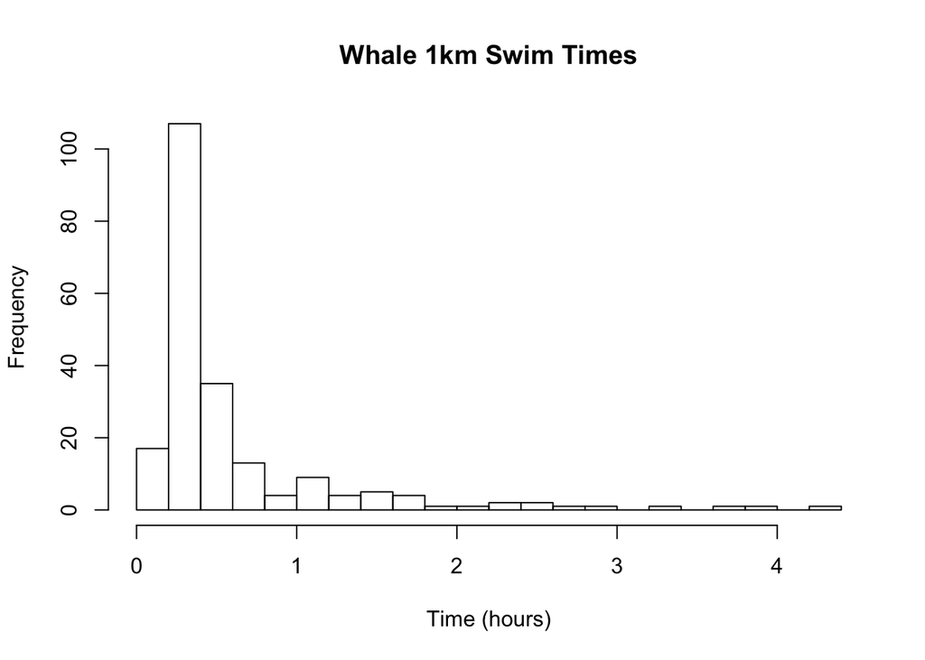

```r
hist(df$time, breaks = 20, main = "Whale 1km Swim Times", xlab = "Time (hours)")
```

Looking at the graph, a gamma distribution does seem like an appropriate guess for the underlying distribution!

### b) Method of Moments Estimates

Method of moments:

```r
#Sample mean
avg <- mean(df$time)

#Sample variance
var <- var(df$time)

#Sample second moment
#print(paste("The sample second moment is ", (var + avg^2)))

#Estimate parameters
mom_alpha <- avg^2/var
mom_lambda <- avg/var

print(paste("The estimated alpha by method of moments is ", mom_alpha))
```

```
## [1] "The estimated alpha by method of moments is  0.795368484304523"
```

```r
print(paste("The estimated lambda by method of moments is ", mom_lambda))
```

```
## [1] "The estimated lambda by method of moments is  1.31249131071988"
```

### c) Maximum Likelihood Estimates

Maximum likelihood estimate, using initial values from method of moments estimate:

```r
mle_estim <- fitdistr(df$time, densfun = "gamma")$estimate

mle_alpha <- mle_estim["shape"]
mle_lambda <- mle_estim["rate"]

print(paste("The estimated alpha by maxmum likelihood is ", mle_alpha))
```

```
## [1] "The estimated alpha by maxmum likelihood is  1.59540844869229"
```

```r
print(paste("The estimated lambda by maximum likelihood is ", mle_lambda))
```

```
## [1] "The estimated lambda by maximum likelihood is  2.63269357989439"
```

While alpha’s (shape’s) estimate is a lot lower (0.79 vs 1.59), lambda’s (rate’s) estimate is greater by about 1.3 (1.3 vs 2.6). In our case, these two estimators give considerably different parameter estimates.

### d) Plotted Guess Distributions

Plot the two gamma densities:

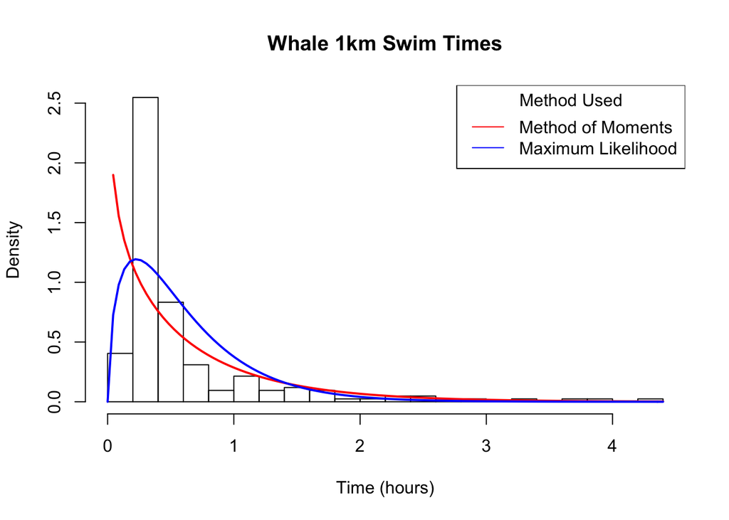

```r
hist(df$time, breaks = 20, freq = FALSE, main = "Whale 1km Swim Times", xlab = "Time (hours)")
curve(dgamma(x, shape = mom_alpha, rate = mom_lambda), lwd = 2, add = TRUE, col = "red")
curve(dgamma(x, shape = mle_alpha, rate = mle_lambda), lwd = 2, add = TRUE, col = "blue")
legend("topright", legend = c("Method of Moments", "Maximum Likelihood"), lty = 1, col = c("red", "blue"), title = "Method Used")
```

It looks like maximum likelihood will give us a better estimate of the true underlying distribution in this case.

### e) Bootstrap: Method of Moments

To estimate our method-of-moments-estimated parameters’ sampling distributions and standard errors, we will use the bootstrap method. This means we will draw 1000 SRS’s of size n=210 each from our gamma curve predicted by method of moments, and estimate alpha and lambda every time (using sample mean and variances). We will then plot these to see our results, and find each estimated parameter’s mean and standard errors. We expect the plots to be approximately normal due to CLT.

```r
#Parametric Bootstrap -- Method of Moments
mom_boot_samples <- replicate(1000, rgamma(210, shape = mom_alpha, rate = mom_lambda)) #1000 samples of size 210 each from gamma dist using MoM estimates
```

First we will focus on the MoM alphas:

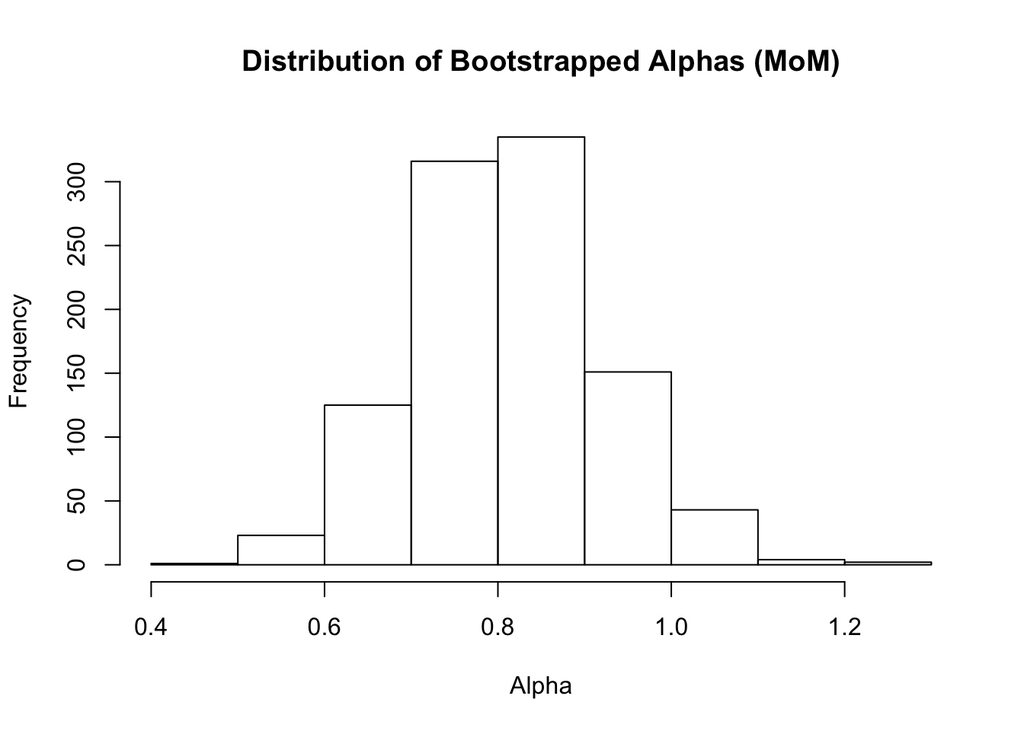

```r
#Calculate bootstrap MoM estimates: alpha
mom_sampling_distr_alphas <- apply(mom_boot_samples, 2, function(x){mean(x)^2/var(x)})

#Visualize bootstrapped alphas
hist(mom_sampling_distr_alphas, main = "Distribution of Bootstrapped Alphas (MoM)", xlab = "Alpha")
```

```r
#Estimate Accuracy of estimated alpha
mom_alpha_mean <- mean(mom_sampling_distr_alphas)
mom_alpha_sd <- sd(mom_sampling_distr_alphas)
print(paste("The mean of MoM bootstrapped alphas is ", mom_alpha_mean))
```

```
## [1] "The mean of MoM bootstrapped alphas is  0.813022755855909"
```

```r
print(paste("The SE of MoM bootstrapped alphas is ", mom_alpha_sd))
```

```
## [1] "The SE of MoM bootstrapped alphas is  0.110018452972311"
```

Next, we will take a look at our bootstrapped MoM lambdas

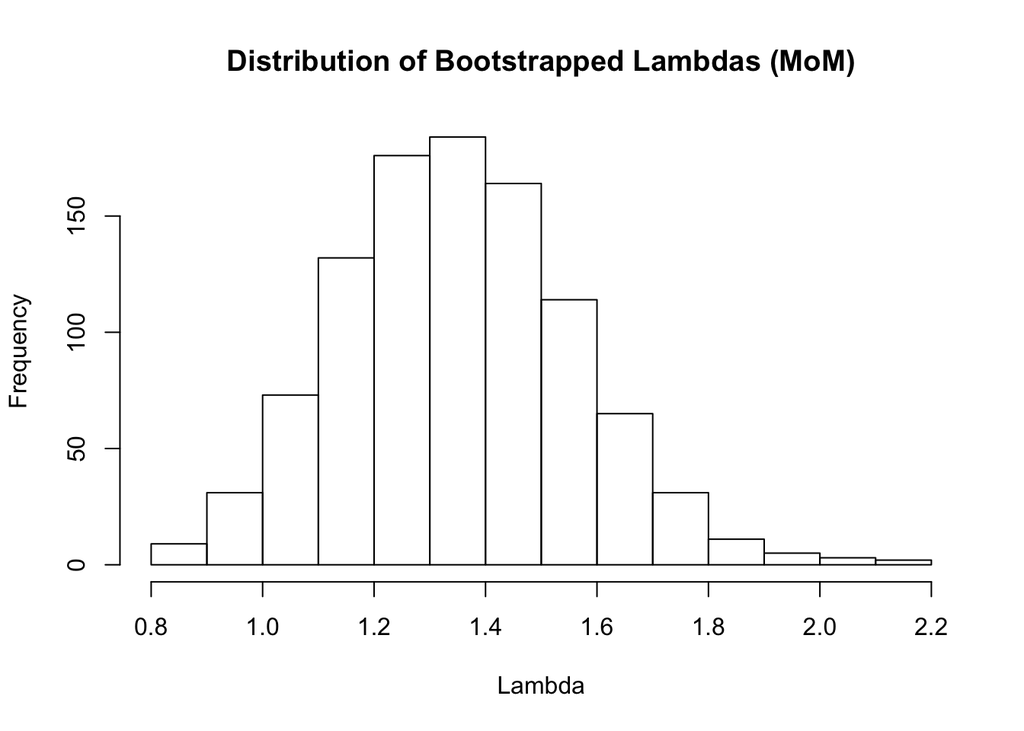

```r
#Calculate bootstrap MoM estimates: lambda
mom_sampling_distr_lambdas <- apply(mom_boot_samples, 2, function(x){mean(x)/var(x)})

#Visualize bootstrapped lambdas
hist(mom_sampling_distr_lambdas, main = "Distribution of Bootstrapped Lambdas (MoM)", xlab = "Lambda")
```

```r
#Estimate Accuracy of estimated lambda
mom_lambda_mean <- mean(mom_sampling_distr_lambdas)
mom_lambda_sd <- sd(mom_sampling_distr_lambdas)
print(paste("The mean of MoM bootstrapped lambdas is ", mom_lambda_mean))
```

```
## [1] "The mean of MoM bootstrapped lambdas is  1.3508033428146"
```

```r
print(paste("The SE of MoM bootstrapped lambdas is ", mom_lambda_sd))
```

```
## [1] "The SE of MoM bootstrapped lambdas is  0.209571032178586"
```

It seems that our estimates are pretty close to our calculated parameters, with reasonable variation!

### f) Bootstrap: Maximum Likelihood

Now we want to do the same bootstrap method, but with the assumed underlying distribution as our gamma distribution as derived by the maximum likelihood estimates. We still expect the plots to be approximately normal due to CLT.

```r
#Parametric Bootstrap -- Maximum Likelihood
mle_boot_samples <- replicate(1000, rgamma(210, shape = mle_alpha, rate = mle_lambda)) #1000 samples of size 210 each from gamma dist using MLE estimates
```

First we will focus on the MLE alphas:

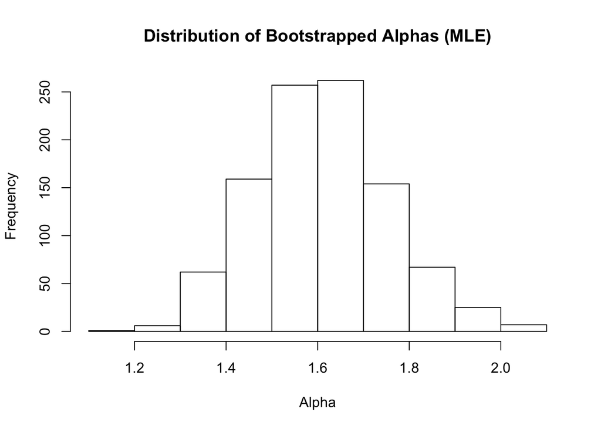

```r
#Calculate bootstrap MoM estimates: alpha
mle_sampling_distr_alphas <- apply(mle_boot_samples, 2, function(x){fitdistr(x, "gamma")$estimate["shape"]})

#Visualize bootstrapped alphas
hist(mle_sampling_distr_alphas, main = "Distribution of Bootstrapped Alphas (MLE)", xlab = "Alpha")
```

```r
#Estimate Accuracy of estimated alpha
mle_alpha_mean <- mean(mle_sampling_distr_alphas)
mle_alpha_sd <- sd(mle_sampling_distr_alphas)
print(paste("The mean of MLE bootstrapped alphas is ", mle_alpha_mean))
```

```
## [1] "The mean of MLE bootstrapped alphas is  1.61007351751102"
```

```r
print(paste("The SE of MLE bootstrapped alphas is ", mle_alpha_sd))
```

```
## [1] "The SE of MLE bootstrapped alphas is  0.145013322693418"
```

Next, we will take a look at our bootstrapped MLE lambdas

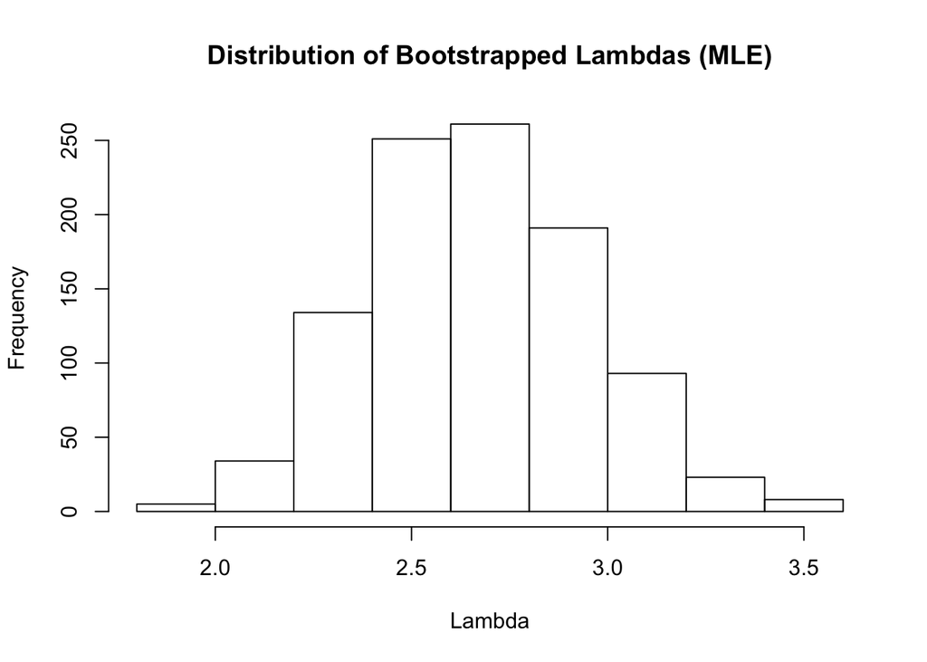

```r
#Calculate bootstrap MoM estimates: lambda
mle_sampling_distr_lambdas <- apply(mle_boot_samples, 2, function(x){fitdistr(x, "gamma")$estimate["rate"]})

#Visualize bootstrapped lambdas
hist(mle_sampling_distr_lambdas, main = "Distribution of Bootstrapped Lambdas (MLE)", xlab = "Lambda")
```

```r
#Estimate Accuracy of estimated lambda
mle_lambda_mean <- mean(mle_sampling_distr_lambdas)
mle_lambda_sd <- sd(mle_sampling_distr_lambdas)
print(paste("The mean of MLE bootstrapped lambdas is ", mle_lambda_mean))
```

```
## [1] "The mean of MLE bootstrapped lambdas is  2.6660337457434"
```

```r
print(paste("The SE of MLE bootstrapped lambdas is ", mle_lambda_sd))
```

```
## [1] "The SE of MLE bootstrapped lambdas is  0.280155495981418"
```

Our bootstrapped estimates are still very close to our original calculations, and are definitely within one bootstrapped SE from each other. The variation in both cases, MoM and MLE, can be easily attributed to chance.

We are proud of ourselves. Good job.

### g) MLE 95% Confidence Intervals

Here we will find confidence intervals for alpha and lambda as derived from our bootstrapping of the maximum likelihood estimate. We will go with a classic 95% confidence interval.

```r
#Alpha CI
print(paste("We are 95% confident that the range (", (mle_alpha_mean - 1.96*mle_alpha_sd), ", ", mle_alpha_mean + 1.96*mle_alpha_sd, ") contains the true alpha."))
```

```
## [1] "We are 95% confident that the range ( 1.32584740503192 ,  1.89429962999012 ) contains the true alpha."
```

```r
#Lambda CI
print(paste("We are 95% confident that the range (", mle_lambda_mean - 1.96*mle_lambda_sd, ",", mle_lambda_mean + 1.96*mle_lambda_sd, ") contains the true lambda."))
```

```
## [1] "We are 95% confident that the range ( 2.11692897361982 , 3.21513851786698 ) contains the true lambda."
```